### False discovery and friends in psycholinguistics

**[Timothy Leffel](http://lefft.xyz), NORC at U Chicago**  
[*draft, updated july23/2017*]

**Abstract.** Simulating RT-based psycholinguistics experiments to understand the role of analysis decisions and power in type-i/-ii errors, false discovery rate, and related problems.

#### set up environment

```r
# NOTE: list of TODO items at bottom of script

# set global chunk options
knitr::opts_chunk$set(
  fig.width=10, fig.height=7, warning=FALSE, message=FALSE
)

# load dependencies
library("dplyr"); library("magrittr"); library("ggplot2"); library("gridExtra")

# set plot theme
theme_set(theme_minimal(14))

# set random seed for reproducibility
set.seed(1234)

# load simulation functions etc.
source("functions.r")
```

#### simulate a simple experiment

Suppose we’re doing an RT experiment + we have just related/unrelated conditions. Further suppose everything is matched on freq/length/etc. (see `functions.r` for definition of `simulate_experiment()` – will make design more complex/realistic in next iteration).

```r
# simulate the experiment a single time
dat <- simulate_experiment()
```

The data look like this:

```r
# display 10 randomly sampled rows of the data
knitr::kable(dat[sample(seq(len=nrow(dat)), size=10), ], digits=2)
```

|  | subj | item | cond | rt | is_outlier | rt_log | rt_ctd | rt_zsc |
| --- | --- | --- | --- | --- | --- | --- | --- | --- |
| 789 | subj_040 | item_09 | related | 262.69 | reggie | 5.57 | -197.40 | -1.72 |
| 1383 | subj_070 | item_03 | related | 413.18 | reggie | 6.02 | -46.92 | -0.41 |
| 1093 | subj_055 | item_13 | _unrelated | 434.83 | reggie | 6.07 | -25.27 | -0.22 |
| 287 | subj_015 | item_07 | related | 542.42 | reggie | 6.30 | 82.32 | 0.72 |
| 392 | subj_020 | item_12 | _unrelated | 214.42 | reggie | 5.37 | -245.67 | -2.14 |
| 886 | subj_045 | item_06 | related | 312.26 | reggie | 5.74 | -147.84 | -1.29 |
| 1965 | subj_099 | item_05 | related | 396.60 | reggie | 5.98 | -63.50 | -0.55 |
| 1968 | subj_099 | item_08 | related | 298.72 | reggie | 5.70 | -161.38 | -1.40 |
| 185 | subj_010 | item_05 | related | 711.85 | _outlier | 6.57 | 251.75 | 2.19 |
| 1123 | subj_057 | item_03 | related | 312.03 | reggie | 5.74 | -148.07 | -1.29 |

We’ve already specified the number of outlier subjs (in the function def’n), but we’ll want to have a couple params around for stuff below. This needs to be cleaned up.

**TODO (important)**: fix this for clarity – *need to set global params for the subsetting etc. below. These are already fed into `simulate_experiment()` as default args, but should be passed explicitly from the global environment for transparency. But need to improve/transparent-ize the argument passing structure in the sim pipeline before that is possible).*

```r
# set params for subsetting below [HACK -- FIX THIS SOON]
n_outlier    <- length(unique(dat$subj[dat$is_outlier=="_outlier"]))
outlier_subj <- unique(dat$subj[dat$is_outlier=="_outlier"])
```

#### plot the raw RT’s

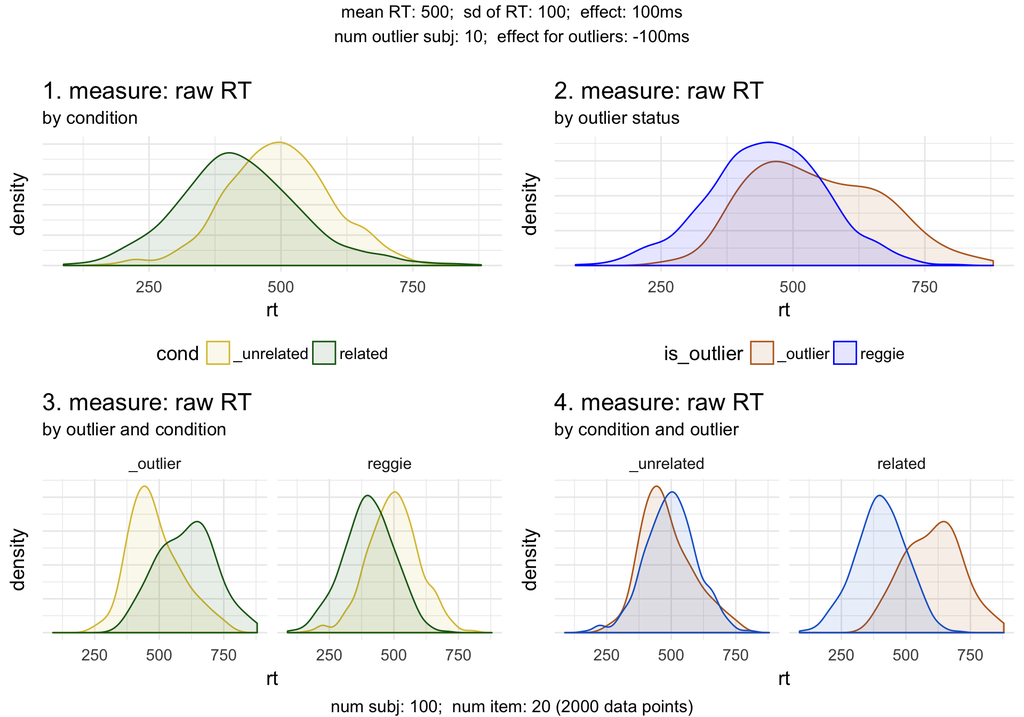

```r
# plot the resutls by condition and outlier status
# (options: rt, rt_log, rt_ctd, rt_zsc)
plot_results(dat, rt_col="rt")
```

*(and summarize them – need to generalize summary func before can do summaries for other RT measures)*

**TODO:** generalize summary func (prob need to implement it w `enquo()` for smoothness ack)

```r
# summarize the results by relevant grouping vars
tabs <- summarize_results(dat)

tabs$summary_by_cond
```

mean RT: 500; sd of RT: 100; effect: 100ms num outlier subj: 10; effect for outliers: -100ms

| cond | num_obs | rt_mean | rt_sd |
| --- | --- | --- | --- |
| _unrelated | 1000 | 497 | 100 |
| related | 1000 | 423 | 117 |

```r
tabs$summary_by_outlier
```

mean RT: 500; sd of RT: 100; effect: 100ms num outlier subj: 10; effect for outliers: -100ms

| is_outlier | num_obs | rt_mean | rt_sd |
| --- | --- | --- | --- |
| _outlier | 200 | 545 | 122 |
| reggie | 1800 | 451 | 110 |

```r
tabs$summary_by_outlier_cond
```

mean RT: 500; sd of RT: 100; effect: 100ms num outlier subj: 10; effect for outliers: -100ms

| is_outlier | cond | num_obs | rt_mean | rt_sd |
| --- | --- | --- | --- | --- |
| _outlier | _unrelated | 100 | 484 | 100 |
| _outlier | related | 100 | 606 | 111 |
| reggie | _unrelated | 900 | 499 | 100 |
| reggie | related | 900 | 403 | 99 |

#### plot the raw RT’s, with outliers excluded

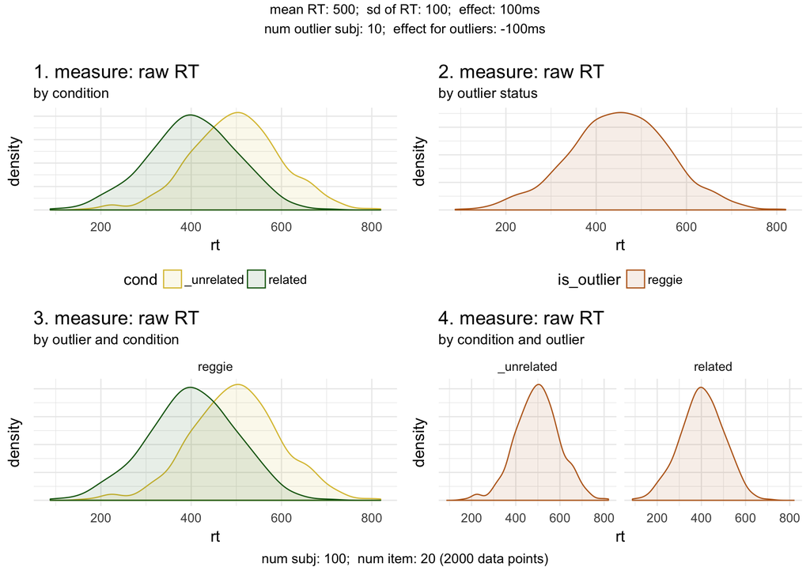

```r
# plot the raw rt's, but with outlier subj's excluded
plot_results(dat[dat$is_outlier=="reggie", ], rt_col="rt")
```

```r
# summarize them too
summarize_results(dat[dat$is_outlier=="reggie", ])$summary_by_cond
```

mean RT: 500; sd of RT: 100; effect: 100ms num outlier subj: 10; effect for outliers: -100ms

| cond | num_obs | rt_mean | rt_sd |
| --- | --- | --- | --- |
| _unrelated | 900 | 499 | 100 |
| related | 900 | 403 | 99 |

#### fit some models [STILL NEEDS WRITTEN]

```r
# [THIS IS THE CRUCIAL PART RITE HERE]
```

**TODO:** encapsulate code in next chunk into a func

```r
# establish + quantify the effect of condition
fit <- lm(rt ~ cond, data=dat)
knitr::kable(summary(fit)$coefficients, caption="<br>model: RT ~ condition")

# add outlier:cond interaction as a predictor + fit
fit_outlier <- lm(rt ~ cond + cond:is_outlier, data=dat)
knitr::kable(summary(fit_outlier)$coefficients,
             caption="<br><br>model: RT ~ condition + condition:outlier")

# evaluate relative fit between the reggie mod + one w outlier interaction term
anova(fit, fit_outlier) # [c("F","Pr(>F)")]
```

model: RT ~ condition

|  | Estimate | Std. Error | t value | Pr(>\|t\|) |
| --- | --- | --- | --- | --- |
| (Intercept) | 497.34028 | 3.440879 | 144.53872 | 0 |
| condrelated | -74.48907 | 4.866138 | -15.30764 | 0 |

model: RT ~ condition + condition:outlier

|  | Estimate | Std. Error | t value | Pr(>\|t\|) |
| --- | --- | --- | --- | --- |
| (Intercept) | 484.32383 | 9.991647 | 48.472873 | 0.0000000 |
| condrelated | 121.25981 | 14.130323 | 8.581532 | 0.0000000 |
| cond_unrelated:is_outlierreggie | 14.46273 | 10.532121 | 1.373202 | 0.1698439 |
| condrelated:is_outlierreggie | -203.03603 | 10.532121 | -19.277792 | 0.0000000 |

```
## Analysis of Variance Table
##
## Model 1: rt ~ cond
## Model 2: rt ~ cond + cond:is_outlier
##   Res.Df      RSS Df Sum of Sq      F    Pr(>F)
## 1   1998 23655620
## 2   1996 19926668  2   3728952 186.76 < 2.2e-16 ***
## ---
## Signif. codes:  0 '***' 0.001 '**' 0.01 '*' 0.05 '.' 0.1 ' ' 1
```

```r
# also: exclude outliers to see how effect size changes relative to `fit`
fit_excl <- lm(rt ~ cond, data=dat[!dat$subj %in% outlier_subj, ])
knitr::kable(summary(fit_excl)$coefficients)
```

|  | Estimate | Std. Error | t value | Pr(>\|t\|) |
| --- | --- | --- | --- | --- |
| (Intercept) | 498.78655 | 3.307233 | 150.81689 | 0 |
| condrelated | -96.23895 | 4.677133 | -20.57648 | 0 |

#### notes to self

```r
# can use either strategy for passing metadata
# comment(dat) <- "boosh!"
# attr(dat, "tim_note") = "boosh!"

# NOTE: also fit the model on logged rt's
# (can use scaled to get sd units too)
# fit_log <- lm(rt_log ~ cond, data=dat); summary(fit_log)

# flow of data in sim setup is:
# generate_data() %>% introduce_outliers() %>% transform_rts()

# NOTE: the attributes of dat$rt_zsc are mean and sd ("center" and "scale")

# width of individual kable()s, use arg: table.attr = "style='width:XXX%;'"
```

We want to simulate a realistic scenario, but we also want to understand why it works the way it does. The approach that we will take is to start by simulating a very simplified scenario, and understanding precisely how it works and which factors it is sensitive to. Then, we will iteratively make the scenario more complicated, each time pausing to ensure we understand the influence of each added layer of abstraction. What we will end up with is a scenario that has all of the parameters and sources of variation as a genuine, lexical-decision based priming study, that uses accuracy and reaction time as dependent measures, and includes by-subject and by-item crossed random effects.

###### Step 0: replicate chemla sim